# DS 202 Homework 3

Muhammad Khairi Norizan

9/26/2021

### Question 1

Explore and explain what is the relationship between the sales price (y) and living area size (x). In your visualization, add a straight line with intercept at 20000 and slope equal to 1000. Look at `?geom_abline`, and in particular the examples. Remark on any patterns you find and the straight line.

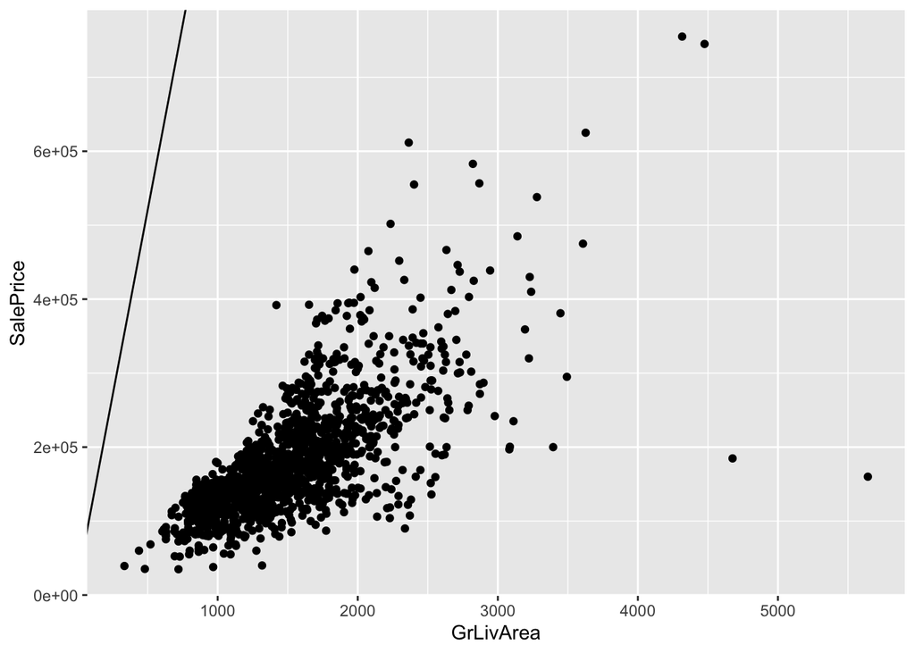

From the graph above, we can see that there are more houses with living area size range between 1000 - 2000 and lesser houses for living area size more than 3000. The graph also explains that, the lower the living area, the lower the price.

### Question 2

Describe at least two types of anomalies in the previous plot. What do they mean?

### Question 3

Visualize the number of sales by the overall condition. Make sure the conditions are ordered from the best to the worst. What do you find?

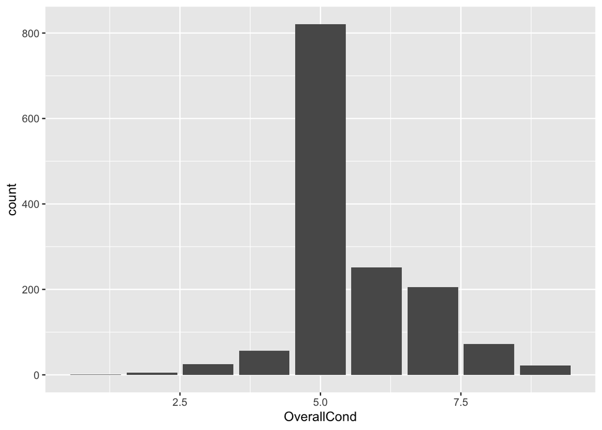

### Question 4

Introduce a variable `houseAge` into the data set which stands for the age of the house at the time when it was sold. How does the age of the house affect the sale price?

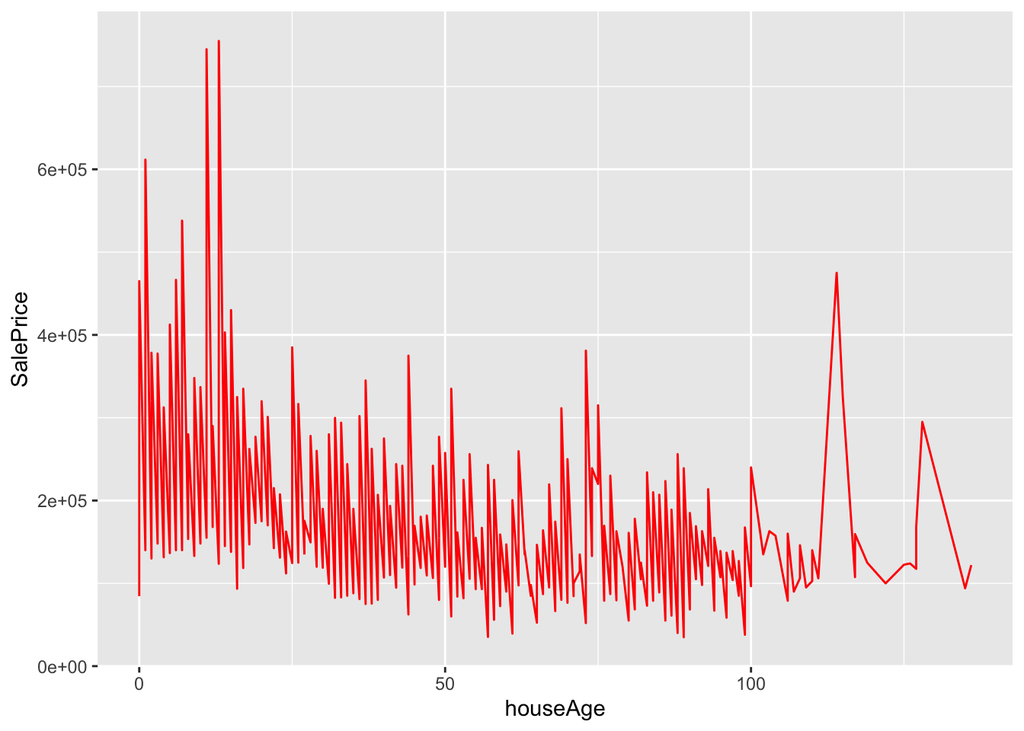

Looking at the correlation:

```
## [1] -0.5233504
```

The correlation between variable `houseAge` and `SalePrice` have a negative correlation. It means that, when the `houseAge` increases, the `SalePrice` decreases. However, the correlation between these two variables is not strong enough which is explained in the graph above.

### Question 5

Were there more sales of nice houses or poor houses? Make sure to state your criterion for a house to be “nice” or otherwise “poor”. Choose an appropriate graph type.

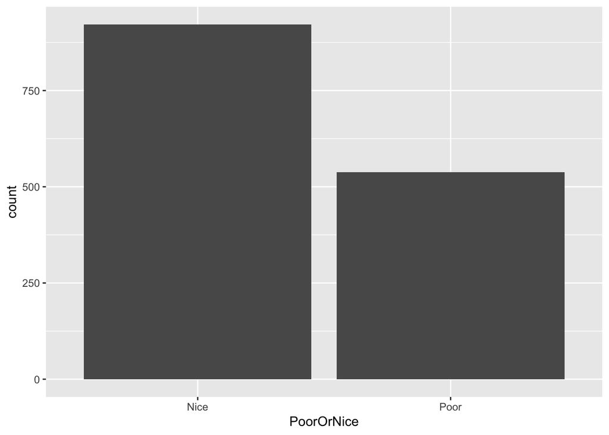

The graph above shows that nice houses have a higher number of sales compared to the poor houses. What is the criterion for nice and poor house? In this case, nice houses is classified as a house that have Overall Quality socre above 5. On the other hand, poor houses are classified as a house that have Overall Quality score 5 and below.

### Question 6

How do the neighborhood and the slope of property affect the relationship between sale price and year built? Focus on the neighborhoods of Brookside, Clear Creek, College Creek, and Somerset only. Find a visualization that incorporates all four variables. Interpret the result.

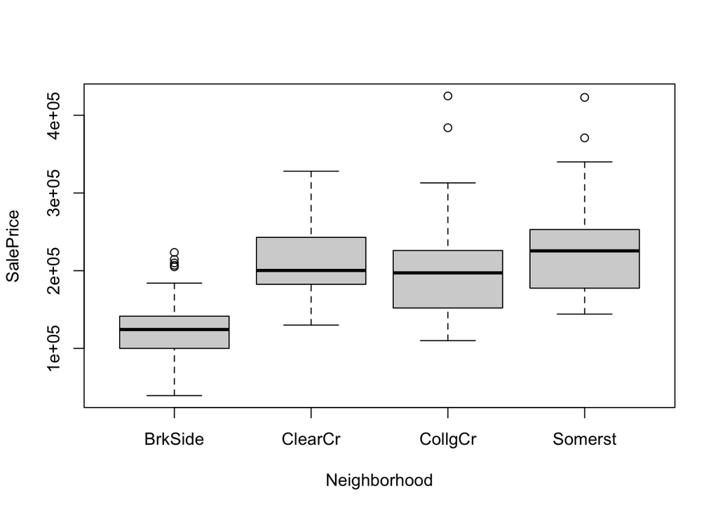

### Question 7

Create a side-by-side histogram showing the sales prices for the different types of buildings. Comment on the result.

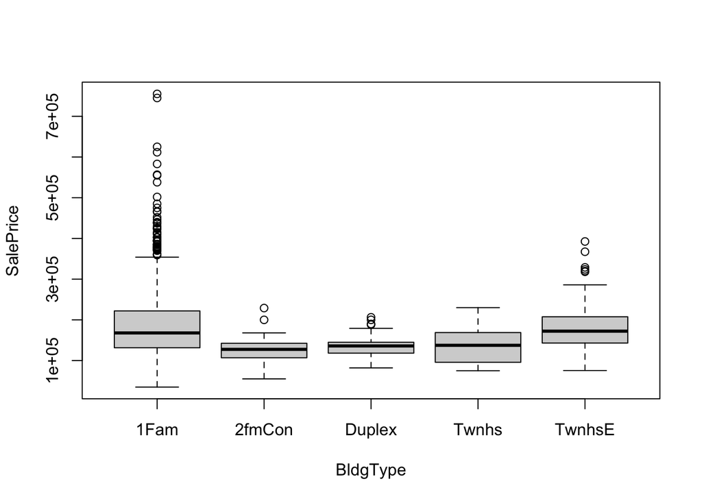

The above box plot shows that a single-family detached building type has the highest sales compared to the rest of the building type. However, looking close, the median sales price for a single-family detached has the same median price for town house end unit. Not only a single-family detached building type has the highest sales, but, the same building type also has the lowest sales prices according to the above graph.

Two-family conversion, duplex, and townhouse inside-unit have lower sales price compared to single-family detached and townhouse end-unit. Moreover, these 3 building types have almost the same median price.

Therefore, depending on the budget, two-family conversion, duplex, and townhouse inside-unit have comparatively lower price compared to single-family detached and townhouse end-unit.